# Using packages to download data

Future Oceans Lab

```
install.packages("devtools")
```

## Obtaining data for research

Welcome to the seminar!

Here we will learn how to download data related with our work in a automated way.

## NOAA

Data from buoys and networks such as NASA and Argo program.

Here the Git Hub repository: httpd://github.com/ropensci/rnoaa

Some examples how to download data from NOAA:

- rnoaa package: meteorological data of NOAA and Argo.
- obpgcrawler: access to data through OpeNDAP (NASA). ie. OceanColor Web.

Get the station info. First you need API Key, this means that you have to go to this link : https://www.ncdc.noaa.gov/cdo-web/token and an email will be sent with your token.

Here an example how it works:

```
install.packages ("rnoaa")
install.packages ("ncdf4")
```

```r
library("rnoaa")
library ("ncdf4")
# Sargaso Sea (Galicia)
buoy(dataset = "stdmet", buoyid = (41049), token = "kRCdMUTNVceWDNMgIpeRLsmjLkvXjeGE")
```

```
## Dimensions (rows/cols): [5544 X 16]
## 13 variables: [wind_dir, wind_spd, gust, wave_height, dominant_wpd, average_wpd, mean_wave_dir, air_pressure, air_temperature, sea_surface_temperature, dewpt_temperature, visibility, water_level]
##
##                    time  lat lon wind_dir wind_spd gust wave_height
## 1  2009-05-14T16:50:00Z 27.5 -63       54      4.7  5.3        1.52
## 2  2009-05-14T17:50:00Z 27.5 -63       32      8.1  9.5        1.78
## 3  2009-05-14T18:50:00Z 27.5 -63       35      8.0  9.1        1.87
## 4  2009-05-14T19:50:00Z 27.5 -63       38      8.0  9.7        1.93
## 5  2009-05-14T20:50:00Z 27.5 -63       27      8.2  9.7        2.15
## 6  2009-05-14T21:50:00Z 27.5 -63       40      8.4 10.3        1.97
## 7  2009-05-14T22:50:00Z 27.5 -63       43      8.6 10.7        1.96
## 8  2009-05-14T23:50:00Z 27.5 -63       33      8.4 10.1        1.97
## 9  2009-05-15T00:50:00Z 27.5 -63       59      7.8 10.5        2.05
## 10 2009-05-15T01:50:00Z 27.5 -63       35      9.3 11.2        2.07
## ..                  ...  ... ...      ...      ...  ...         ...
## Variables not shown: dominant_wpd (dbl), average_wpd (dbl), mean_wave_dir
##      (int), air_pressure (dbl), air_temperature (dbl),
##      sea_surface_temperature (dbl), dewpt_temperature (dbl), visibility
##      (dbl), water_level (dbl)
```

At this direction you can see all buoys you have: http://www.ndbc.noaa.gov/

Also, you can get all info from a city:

```
ncdc_datacats(locationid = 'CITY:US390029', token = "kRCdMUTNVceWDNMgIpeRLsmjLkvXjeGE")
```

## GBIF

Global Biodiversity Information Facility

```
devtools::install_github("ropensci/rgbif")
install.packages ("rgbif")
install.packages("openssl")
install.packages("rgeos")
install.packages("maps")
```

```r
library("rgbif")
library("openssl")
library("rgeos")
library("maps")

occ_count(basisOfRecord = "OBSERVATION")
```

```
## [1] 29816063
```

```r
out <- name_lookup(query = "crustaceans",
                   rank = "PHYLUM",
                   status = "ACCEPTED")

occ_search(scientificName = "Pollicipes pollicipes", limit = 50)
```

```
## Records found [196]
## Records returned [50]
## No. unique hierarchies [1]
## No. media records [7]
## No. facets [0]
## Args [limit=50, offset=0, scientificName=Pollicipes pollicipes,
##      fields=all]
## # A tibble: 50 x 77
##                     name        key decimalLatitude decimalLongitude
##                    <chr>      <int>           <dbl>            <dbl>
##  1 Pollicipes pollicipes 1562950050        43.40472        -2.684444
##  2 Pollicipes pollicipes 1453077645        40.18607        -8.909251
##  3 Pollicipes pollicipes 1453054905        40.55860        -8.771257
##  4 Pollicipes pollicipes 1545696303        55.23298        -6.401470
##  5 Pollicipes pollicipes 1453547681        40.18540        -8.909504
##  6 Pollicipes pollicipes 1453049455        40.59698        -8.757541
##  7 Pollicipes pollicipes  899943530        40.55955        -8.772197
##  8 Pollicipes pollicipes 1544661415        50.04306        -5.631111
##  9 Pollicipes pollicipes  923103256        37.09359        -8.394156
## 10 Pollicipes pollicipes 1005100743        32.30000        -9.240000
## # ... with 40 more rows, and 73 more variables: issues <chr>,
## #   datasetKey <chr>, publishingOrgKey <chr>, publishingCountry <chr>,
## #   protocol <chr>, lastCrawled <chr>, lastParsed <chr>, crawlId <int>,
## #   extensions <chr>, basisOfRecord <chr>, taxonKey <int>,
## #   kingdomKey <int>, phylumKey <int>, classKey <int>, orderKey <int>,
## #   familyKey <int>, genusKey <int>, speciesKey <int>,
## #   scientificName <chr>, kingdom <chr>, phylum <chr>, order <chr>,
## #   family <chr>, genus <chr>, species <chr>, genericName <chr>,
## #   specificEpithet <chr>, taxonRank <chr>, dateIdentified <chr>,
## #   year <int>, month <int>, day <int>, eventDate <chr>, modified <chr>,
## #   lastInterpreted <chr>, references <chr>, license <chr>,
## #   identifiers <chr>, facts <chr>, relations <chr>, geodeticDatum <chr>,
## #   class <chr>, countryCode <chr>, country <chr>, rightsHolder <chr>,
## #   identifier <chr>, verbatimEventDate <chr>, datasetName <chr>,
## #   verbatimLocality <chr>, collectionCode <chr>, gbifID <chr>,
## #   occurrenceID <chr>, taxonID <chr>, catalogNumber <chr>,
## #   recordedBy <chr>, http...unknown.org.occurrenceDetails <chr>,
## #   institutionCode <chr>, rights <chr>, eventTime <chr>,
## #   occurrenceRemarks <chr>, identificationID <chr>,
## #   coordinateUncertaintyInMeters <dbl>, stateProvince <chr>,
## #   recordNumber <chr>, eventID <chr>, occurrenceStatus <chr>,
## #   vernacularName <chr>, taxonConceptID <chr>, locality <chr>,
## #   created <chr>, associatedSequences <chr>, higherClassification <chr>,
## #   identifiedBy <chr>
```

Making a simple map (https://github.com/ropensci/rgbif)

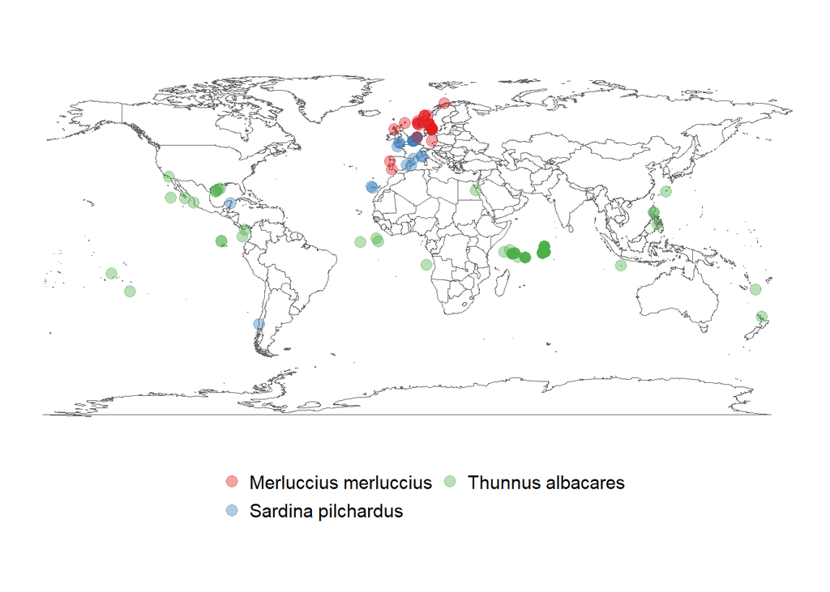

```r
splist <- c('Sardina pilchardus', 'Thunnus albacares', 'Merluccius merluccius')
keys <- sapply(splist, function(x) name_backbone(name=x)$speciesKey, USE.NAMES=FALSE)
dat <- occ_search(taxonKey = keys, limit=100, return='data', hasCoordinate=TRUE)
library('plyr')
datdf <- ldply(dat)
gbifmap(datdf)
```

## Fishbase

Link to Git Hub https://github.com/ropensci/rfishbase

```
install.packages("rfishbase")
library("rfishbase")
```

```r
library("rfishbase")
Species <- read.csv("data/Species_UE.csv")
Species2<-as.character(Species$SPECIE)
str(Species2, vec.len = 100)
```

```
##  chr [1:96] "Amblyraja radiata" "Ammodytes spp." "Argentina silus" "Beryx spp." "Brosme brosme" "Caproidae" "Centrophorus squamosus" "Centrocymnus coelolepis" "Chaceon spp." "Chaenocephalus aceratus" "Champsocephalus gunnari" "Channichthys rhinoceratus" "Chinoecetes spp." "Clupea harengus" "Coryp…
```

```r
#Here we copy-paste the solution and add commas to the string to run the next code

a<- c("Amblyraja radiata", "Ammodytes spp.", "Argentina silus", "Beryx spp.", "Brosme brosme", "Caproidae", "Centrophorus squamosus", "Centrocymnus coelolepis", "Chaceon spp.","Chaenocephalus aceratus", "Champsocephalus gunnari", "Channichthys rhinoceratus", "Chinoecetes spp.", "Clupea harengus", "Coryphaenoides rupestris", "Dalatias licha","Deania calcea","Dicentrarchus labrax", "Dipturus batis","Dissostichus eleginoides", "Dissostichus mawsoni", "Dissostichus spp.","Engraulis encrasicolus", "Etmopterus princeps", "Etmopterus pusillus", "Euphausia superba", "Gadus morhua", "Galeorhinus galeus", "Glyptocephalus cynoglossus", "Gobionotothen gibberifrons", "Hippoglossoides platessoides", "Hippoglossus hippoglossus", "Hoplostethus atlanticus", "Illex illecebrosus","Istiophorus albicans", "Lamma nasus", "Lepidonotothen aquamifrons", "Lepidorhombus spp.", "Leucoraja naevus", "Limanda ferruginea", "Limanda limanda", "Lophiidae", "Macrourus spp.", "Makaira nigricans", "Mallotus villosus", "Manta birostris", "Martialia hyadesi","Melanogrammus aeglefinus", "Merlangius merlangus", "Merluccius merluccius", "Micromesistius poutassou", "Microstomus kitt", "Molva dypterygia", "Molva molva", "Nephrops norvegicus", "Notothenia rossi", "Pandalus borealis", "Paralomis spp", "Penaeus spp. ", "Platichthys flesus", "Pleuronectes platessa", "Pleuronectiformes", "Pollachius pollachius", "Pollachius virens", "Prionace glauca", "Psetta maxima", "Pseudochaenichthys georgianus", "Pseudopentaceros spp.", "Rostroraja alba", "Raja brachyura", "Raja circularis", "Raja clavata", "Raja fullonica", "Dipturus nidarosiensis", "Raja microocellata", "Raja montagui", "Raja undulata", "Rajiformes", "Reinhardtius hippoglossoides", "Sardina pilchardus", "Scomber scombrus", "Scophthalmus rhombus", "Sebastes spp.", "Solea solea", "Sprattus sprattus", "Squalus acanthias", "Tetrapturus albidus", "Thunnus albacares", "Thunnus maccoyii", "Thunnus obesus", "Thunnus thynnus", "Trachurus murphyi", "Trachurus spp.", "Trisopterus esmarkii", "Urophycis tenuis", "Xiphias gladius")


dat <- species(a, fields=c("SpecCode", "PriceCateg", "Vulnerability"))
dat
```

```
##                          sciname Vulnerability PriceCateg SpecCode
## 1              Amblyraja radiata         58.70     medium     2565
## 2                Argentina silus         51.18  very high     2700
## 3                  Brosme brosme         62.55        low       51
## 4         Centrophorus squamosus         85.50     medium      653
## 5        Chaenocephalus aceratus         68.29       high      473
## 6        Champsocephalus gunnari         35.26  very high      474
## 7      Channichthys rhinoceratus         45.65  very high      477
## 8                Clupea harengus         38.77        low       24
## 9       Coryphaenoides rupestris         66.51        low      332
## 10                Dalatias licha         65.06     medium      669
## 11                 Deania calcea         65.80     medium      670
## 12          Dicentrarchus labrax         49.43  very high       63
## 13                Dipturus batis         86.21     medium     2058
## 14      Dissostichus eleginoides         71.35  very high      467
```

[output cut: 53 more lines]

```r
resil <- stocks(a, fields="Resilience")
sp <- merge(dat, resil)

#ecosystem(species_list = NULL, fields = NULL, query = NULL, limit = 200,
  #server = getOption("FISHBASE_API", FISHBASE_API), ...)
```

To finish the seminar I leave you some interesting links:

An introduction to basic fisheries analysis with R - https://sfg-ucsb.github.io/fishery-manageR/

Happy Git and GitHub for the useR - http://happygitwithr.com/

DataONE. Data Observation Network on Earth. At this link you can download articles and papers related with your work using a key word. - https://search.dataone.org/#data.

Enjoy!